# NFL field goal attempts: modeling the long shots

James R Bland (https://sites.google.com/site/jamesbland/)

November 25, 2019

A few days ago, I [estimated a 1-parameter model of NFL field goal attempts](https://jamesblandecon.github.io/NFLFieldGoals.html) using data from [pro-football-reference.com](https://www.pro-football-reference.com/play-index/fg_finder.cgi). While it did reasonably well for most distances, it was especially terrible for the long shots ($>60$ yards), so today I will add another two parameters to hopefully model these a bit better.

H/T to Will Harrison (@willjharrison) for suggesting this!

## The new part of the model

I alluded to a slightly more complicated version of this in the previous post. Here, I assume that players’ range (how far they can kick the ball and still have it go over the horizontal bar) is distributed $N(m,s)$, so the probability of making the distance is $1-\Phi((x-m)/s)$. Hence, the probability of a successful field goal attempt at $x$ yards from goal is:
$$\Pr\left(\text{angle good} \mid x,\kappa,m,s\right)=\underbrace{\left(1-\Phi((x-m)/s)\right)}_{\text{distance}}\underbrace{\left(1-2\Phi\left(\kappa^{-1}\cos^{-1}\left(\frac{x}{\sqrt{x^2+d^2/4}}\right)\right)\right)}_\text{angle (my old model)}$$

I assign an informative prior over $m$ so that this effect can only be important for long distances. Specifically: $m\sim N(60,3)$. Note that for the distance component of the model, the probability is declining fastest at $x=m$.

# Estimating the model in Stan

```c
// FieldGoalsCountDistance.stan
functions {


}
data {
  // Tell Stan how to read in the data
  int n; // Number of observations
  real d;
  int  y[n]; // =count of scored
  int  N[n]; // number of attempts from that distance
  vector[n]  Distance; //
  real priorK[2];
  real priorM[2];
  real priorS;

}
transformed data {

}
parameters {
  real<lower=0> k;
  real m;
  real<lower=0> s;

}
transformed parameters {

}
model {
    vector[n] pAngle;
    vector[n] pDistance;
    vector[n] p;
    for (ii in 1:n) {
        pAngle[ii] =  1-2*normal_cdf(-acos(Distance[ii]/sqrt(Distance[ii]^2+d^2/4.0)),0.0,k);
        pDistance[ii] = max({1.0-normal_cdf(Distance[ii],m,s),0.000001});
        p[ii] = pAngle[ii]*pDistance[ii];
    }

  k ~ lognormal(priorK[1],priorK[2]);
  m ~ normal(priorM[1],priorM[2]);
  s ~ exponential(priorS);
  y ~ binomial(N,p);


  }
generated quantities {

}
```

## Results for all data at once

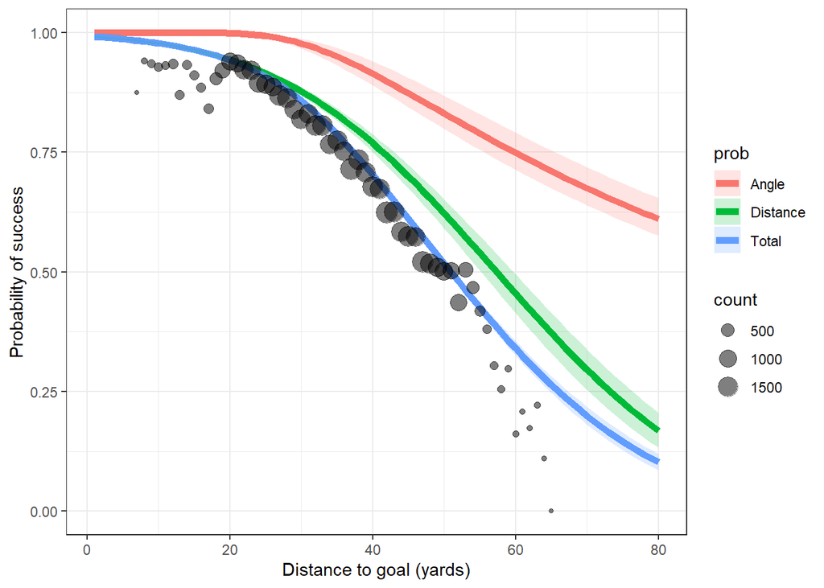

```r
AggData<-aggregate(Data[,c("Dist","Y","B")],by=list(Data$Dist),FUN=mean)
#
AggData$count<-aggregate(Data[,c("Dist")], by=list(Data$Dist),FUN=length)$x
AggData<-AggData[AggData$Dist<=65,]
#
  k<-extract(FitALL)$k
  m<-extract(FitALL)$m
  s<-extract(FitALL)$s
  x<-seq(1,80)
  angle<-acos(x/sqrt(x^2+d^2/4))
  pltData<-data.frame()
  for (xx in 1:length(x)) {
    pAngle<-1-2*pnorm(-angle[xx]/k)
    pDistance<-1-pnorm((x[xx]-m)/s)
    pTotal<-pAngle*pDistance

    p<-pAngle
    tmp<-data.frame(p)
    tmp$x<-x[xx]
    tmp$prob<-"Angle"
    pltData<-rbind(pltData,tmp)
    p<-pDistance
    tmp<-data.frame(p)
    tmp$x<-x[xx]
    tmp$prob<-"Distance"
    pltData<-rbind(pltData,tmp)
    p<-pTotal
    tmp<-data.frame(p)
    tmp$x<-x[xx]
    tmp$prob<-"Total"
    pltData<-rbind(pltData,tmp)
  }
  pltD<-aggregate(pltData,by=list(pltData$x,pltData$prob),FUN=mean)
  pltD$prob<-pltD$Group.2
  pltD$pl<-aggregate(pltData$p,by=list(pltData$x,pltData$prob),FUN='quantile',probs=0.025)$x
  pltD$pu<-aggregate(pltData$p,by=list(pltData$x,pltData$prob),FUN='quantile',probs=0.975)$x


  plt<-ggplot(pltD,aes(x=x,y=p))+geom_line(size=2,aes(color=prob))+geom_ribbon(aes(ymin=pl,ymax=pu,fill=prob),alpha=0.2,linetype="blank")
  plt<-plt+geom_point(data=AggData,aes(x=Dist,y=Y,size=count),alpha=0.5)
  plt<-plt+xlab("Distance to goal (yards)")+ylab("Probability of success")+theme_bw()
  plt
```

Here I plot the two components of the model separately (angle and distance), as well as the total prediction, which is equal to their product.

## Results by season

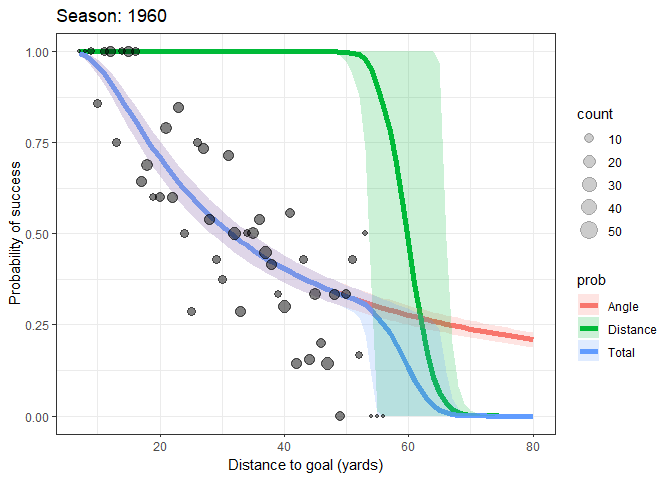

```r
SimSeason<-readRDS("NFLFieldGoalsData/SimSeasonDistance.rds")
AD<-aggregate(Data[,c("season","Dist","Y")],by=list(Data$season,Data$Dist),FUN=mean)
AD$count<-aggregate(Data[,c("season","Dist","Y")],by=list(Data$season,Data$Dist),FUN=length)$Y
AD<-AD[,c("season","Dist","Y","count")]
AD$x<-AD$Dist

SeasonList<-seq(1960,2019)
x<-seq(7,80)
pltData<-data.frame()
for (xx in 1:length(x)) {
  a<-acos(x[xx]/sqrt(x[xx]^2+d^2/4))
  #
  D<-SimSeason
  D$pAngle<-1-2*pnorm(-a/D$k)
  D$pDistance<-1-pnorm((x[xx]-D$m)/D$s)
  D$pTotal<-D$pAngle*D$pDistance

    p<-D$pAngle
    tmp<-data.frame(p)
    tmp$season=D$season
    tmp$x<-x[xx]
    tmp$prob<-"Angle"
    pltData<-rbind(pltData,tmp)
    p<-D$pDistance
    tmp<-data.frame(p)
    tmp$season=D$season
    tmp$x<-x[xx]
    tmp$prob<-"Distance"
    pltData<-rbind(pltData,tmp)
    p<-D$pTotal
    tmp<-data.frame(p)
    tmp$season=D$season
    tmp$x<-x[xx]
    tmp$prob<-"Total"
    pltData<-rbind(pltData,tmp)
  #

}

  pltD<-aggregate(pltData$p,by=list(pltData$x,pltData$prob,pltData$season),FUN=mean)
  pltD$prob<-pltD$Group.2
  pltD$pl<-aggregate(pltData$p,by=list(pltData$x,pltData$prob,pltData$season),FUN='quantile',probs=0.025)$x
  pltD$pu<-aggregate(pltData$p,by=list(pltData$x,pltData$prob,pltData$season),FUN='quantile',probs=0.975)$x


  pltD$season<-pltD$Group.3
  pltD$p<-pltD$x
  pltD$x<-pltD$Group.1

  AD$x<-AD$Dist
  pD<-merge(pltD,AD,by=c("season","x"),all=TRUE)

  plt<-ggplot(pD,aes(x=x,y=p))+geom_line(size=2,aes(color=prob))+geom_ribbon(aes(ymin=pl,ymax=pu,fill=prob),alpha=0.2,linetype="blank")
  plt<-plt+geom_point(aes(x=x,y=Y,size=count),alpha=0.2)
  plt<-plt+transition_time(season)
  plt<-plt+xlab("Distance to goal (yards)")+ylab("Probability of success")
  plt<-plt+theme_bw()
  plt<-plt+labs(title = 'Season: {frame_time}')
  animate(plt, nframes = length(SeasonList)*2)
```

Here is a comparison between the 1960 and 2018 seasons:

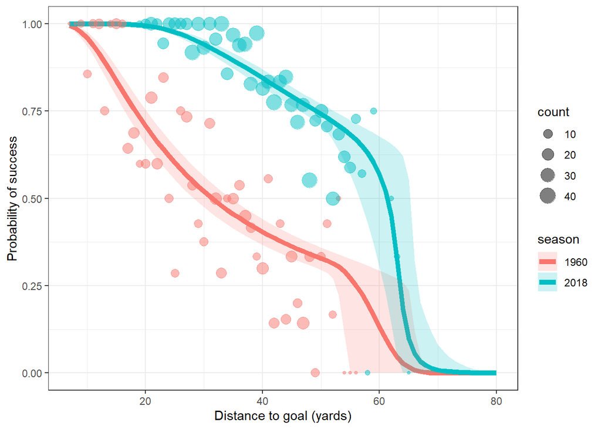

```r
#
D<-pD[pD$season==2018 | pD$season==1960,]
D<-D[D$prob=="Total",]
D$season<-paste(D$season)
  plt<-ggplot(D,aes(x=x,y=p,color=season,group=season))+geom_line(size=2,aes())+geom_ribbon(aes(ymin=pl,ymax=pu,fill=season),alpha=0.2,linetype="blank")
  plt<-plt+geom_point(aes(x=x,y=Y,size=count),alpha=0.5)
  plt<-plt+xlab("Distance to goal (yards)")+ylab("Probability of success")
  plt<-plt+theme_bw()
  plt
```

So it’s a bit of a mess, but if you are OK with interpreting the red line as angle accuracy, and the green line as kick range, then it seems like both have improved since 1960, and most of the gains have been in angle accuracy.

## APPENDIX: estimating the models in R

```r
#FieldGoals_EstimateBinomialDistance.R

rm(list=ls())
setwd("C:/Users/jbland/OneDrive - University of Toledo/General notes on structural Bayes/Sports")
library(foreign)
library(xtable)
library(ggplot2)
library(gganimate)
library(gifski)
library(png)
library("rstan") # observe startup messages
rstan_options(auto_write = TRUE)
Sys.setenv(LOCAL_CPPFLAGS = '-march=native')
options(mc.cores = parallel::detectCores())



Data<-data.frame(read.csv("C:/Users/jbland/OneDrive - University of Toledo/General notes on structural Bayes/Sports/FieldGoalsDataScrape.csv"))
Data$Y<-as.integer(Data$Good=="Y")
Data$B<-as.integer(Data$Blk=="Y")
Data$year<-as.integer(format(as.Date(Data$Date), "%Y"))
Data$month<-as.integer(format(as.Date(Data$Date), "%m"))
Data$season<-Data$year-as.integer(Data$month<=8)

# remove blocked attempts
Data<-Data[Data$B==0,]

# Distance between goal posts 18 feet 6 inches
d<-18.5/3

Data$Angle<-acos(Data$Dist/sqrt(Data$Dist^2+d^2/4))

## ALL ATTEMPTS

D<-Data
DCount<-aggregate(D,by=list(D$Dist),FUN=length)
N<-DCount$Y
y<-aggregate(D,by=list(D$Dist),FUN=mean)$Y*N
Angle<-aggregate(D,by=list(D$Dist),FUN=mean)$Angle
Distance<-aggregate(D,by=list(D$Dist),FUN=mean)$Dist
StanData<-list(d=d,Distance=Distance,y=as.integer(y),N=N,n=length(Angle),priorK=c(log(pi),pi/8),priorM=c(60,3),priorS=1)
FitALL<-stan("FieldGoalsCountDistance.stan",data=StanData,seed=42)
saveRDS(FitALL, "NFLFieldGoalsData/NFLFieldGoalsALLDistance.rds")


# By Season
if (TRUE) {
SeasonList<-unique(Data$season)
SimSeason<-data.frame()
for (ss in 1:length(SeasonList)) {
  D<-Data[Data$season==SeasonList[ss],]
  DCount<-aggregate(D,by=list(D$Dist),FUN=length)
  N<-DCount$Y
  y<-aggregate(D,by=list(D$Dist),FUN=mean)$Y*N
  Angle<-aggregate(D,by=list(D$Dist),FUN=mean)$Angle
  Distance<-aggregate(D,by=list(D$Dist),FUN=mean)$Dist
  StanData<-list(d=d,Distance=Distance,y=as.integer(y),N=N,n=length(Angle),priorK=c(log(pi),pi/8),priorM=c(60,3),priorS=1)
  Fit<-stan("FieldGoalsCountDistance.stan",data=StanData,seed=42,control = list(adapt_delta = 0.999))
  k<-extract(Fit, permuted = TRUE)$k
  m<-extract(Fit)$m
  s<-extract(Fit)$s
  tmp<-data.frame(k,m,s)
  tmp$season<-SeasonList[ss]
  SimSeason<-rbind(SimSeason,tmp)
  print(paste("---",SeasonList[ss],"---",ss,"of",length(SeasonList)))
}
saveRDS(SimSeason,"NFLFieldGoalsData/SimSeasonDistance.rds")
}
```